# 01-quiz-inclass.Rmd

Charlie Reinhardt

Question 1 (5 points). Consider the following graph:

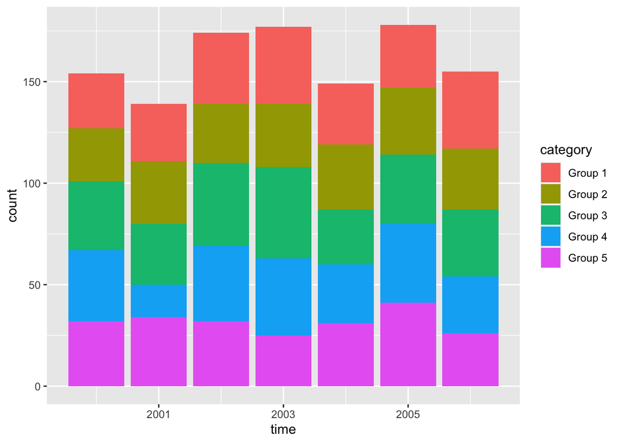

```r
library(tidyverse)
category <- rep(c("Group 1", "Group 2", "Group 3", "Group 4", "Group 5"), 7)
time <- rep(c(2000, 2001, 2002, 2003, 2004, 2005, 2006), each = 5)
response <- rpois(length(category), 30)
df <- tibble(category, time, response)
ggplot(data = df, aes(x = time, y = response)) +
  geom_col(aes(fill = category)) +
  labs(y = "count")
```

Question 2 (4 points). Take the chart from Question 1 and use faceting to display the data from df in each group instead of colour.

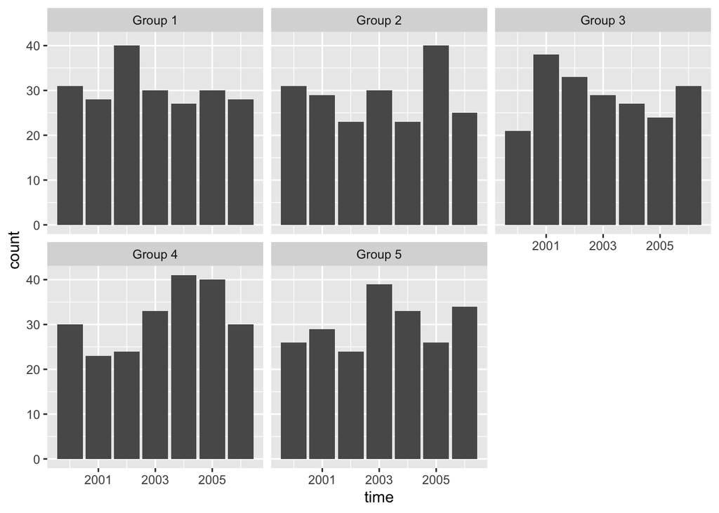

```r
category <- rep(c("Group 1", "Group 2", "Group 3", "Group 4", "Group 5"), 7)
time <- rep(c(2000, 2001, 2002, 2003, 2004, 2005, 2006), each = 5)
response <- rpois(length(category), 30)
df <- tibble(category, time, response)
ggplot(data = df, aes(x = time, y = response)) +
  geom_col() +
  facet_wrap(~category) +
  labs(y = "count")
```

Question 3a (3 points). Suppose that we want to make a map of the United States, and colour each state by the percent change in Covid cases this week compared to last week. States with an increase would have a positive percent change while states with a decrease would have a negative percent change. Should we use a sequential, diverging, or unordered colour scale to colour the states? Give a one phrase or one sentence explanation.

We should use a diverging color scale, as it would allow us to properly show two directions of change (change into the positive and change into the negative), as well as a neutral middle (no change)

Question 3b (3 points). Suppose that, in our map, we now want to colour the states by the number of covid cases per 100,000 people. Should we use a sequential, diverging, or unordered colour scale to colour the states? Give a one phrase or one sentence explanation.

We should use a sequential color scale, because it will allow us to differentiate between different intensities/densities of covid cases in one direction (more color, more covid cases)

Question 4 (4 points). Which of the parameters in the Grammar of Graphics are explicitly specified or changed in the following plot:

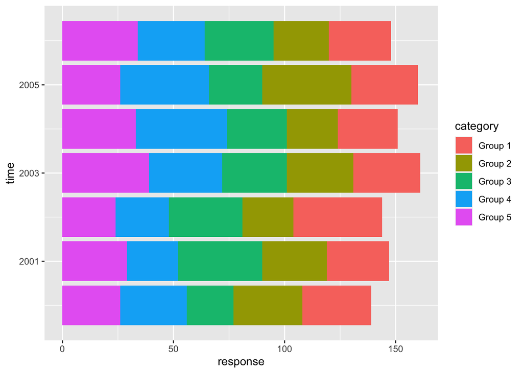

```r
ggplot(data = df, aes(x = time, y = response)) +
  geom_col(aes(fill = category)) +
  coord_flip()
```

DATA, MAPPINGS, GEOM_FUNCTION, and COORDINATE_FUNCTION

Question 5a. (2 points). What would you need to change in the code below so that the points are all coloured blue? Make the change and then give a one sentence explanation of why you need to make that change.

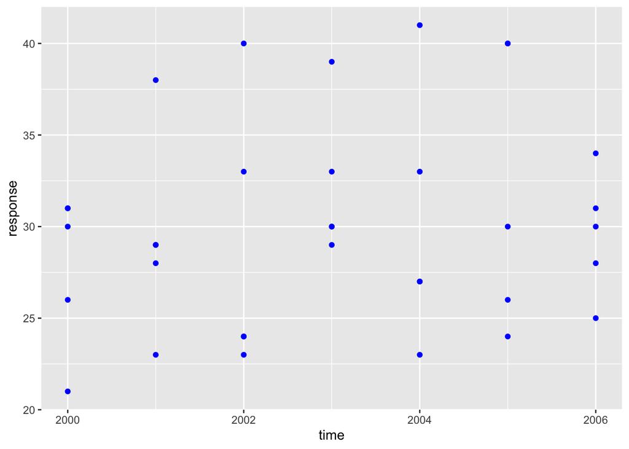

```r
ggplot(data = df, aes(x = time, y = response)) +
  geom_point(colour = "blue")
```

You have to change `aes(colour = "blue")` to `colour = "blue"` (remove it from the aes() wrapping). This is because the aes wrapping makes the color depend on a variable (in this case, an arbitrary category named “blue”), whereas we want to just declare the color of the geom_point to blue.

Question 5b (4 points). What would you need to change in the code below to only have a single smoother for an overall trend (instead of one smoother for each category)? Make the change and then give a one sentence explanation of why you need to make that change.

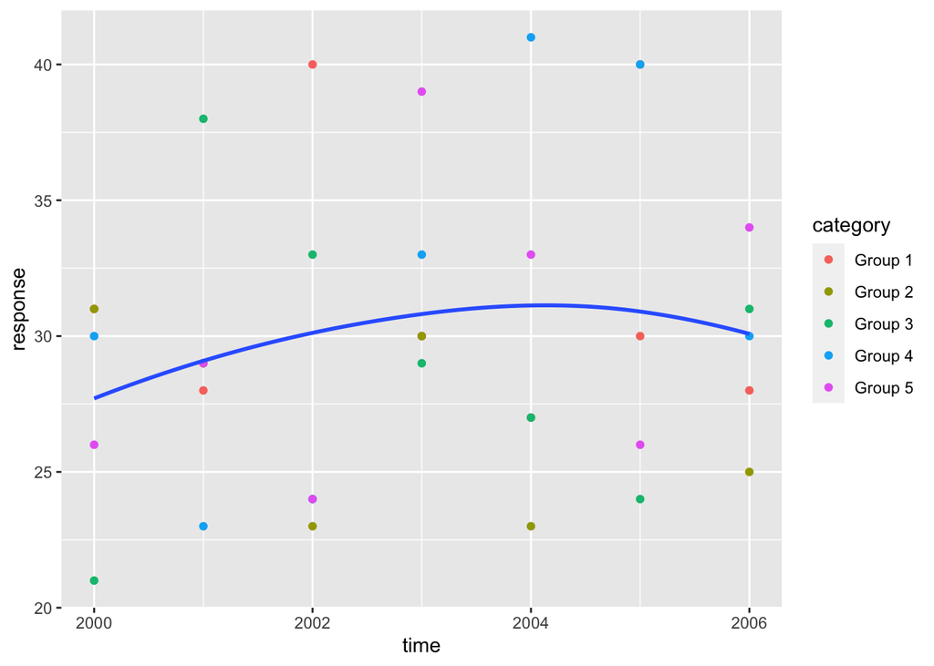

```r
ggplot(data = df, aes(x = time, y = response)) +
  geom_point(aes(colour = category)) +
  geom_smooth(se = FALSE, span = 1.9)
```

Move the `colour = category` into an `aes()` function of geom_point, instead of declaring it as a global aesthetic. This way, `geom_smooth` does not inherit the global aesthetic of separate colors for each category.